# TidyBiology Final Project

Chris Mansfield

11/15/2020

## Background

### Molecular Chaperones in *Plasmodium* Parasites

*Plasmodium* parasites are the causative agents of Malaria. They have a complex life cycle going from a mosquito vector, and, after transmission, establish a dual-stage infection in the liver and erythrocytes of a human host. They are subjected to extreme environmental stress as they progress through these developmental microenvironments, and as they persist through extended periods of extreme temperature during malarial fever. As an adaptation, **they have a highly active *molecular chaperone* system to maintain proteostasis**. In particular, Hsp90 and associated co-chaperones facilitate re-folding and/or degradation of stress-denatured proteins.While Hsp90 is widely conserved (albeit has a 6 times higher ATPase activity in *Plasmodium* than humans, reflecting higher demands), co-chaperones differ between species and serve as regulatory mechanisms for Hsp90 activity. A large complement of co-chaperones are known for humans, but not for *Plasmodium*. **The purpose of this investigation was to determine potential *Plasmodium* co-chaperones based on a potential Hsp90 binding motif across the proteome and correlate it with RNAseq expression data at through the developmnent of infection.**

## Analysis

### Datasets

Three public access datasets were primarily used for analysis: 1) the human proteome from UniProt, 2) the *Plasmodium falciparum* proteome from UniProt, and 3) *Plasmodium falciparum* blood-stage RNAseq from PlasmoDB. RNAseq data from four time-points post-infection were taken and combined to a single timeline dataset. Here are some glimpses inside the datasets:

#### The Proteome Datasets

```
## Rows: 75,069
## Columns: 8
## $ Entry           <chr> "Q8N7X0", "Q5T1N1", "Q92667", "Q5VUY0", "P62736", "...
## $ `Entry name`    <chr> "ADGB_HUMAN", "AKND1_HUMAN", "AKAP1_HUMAN", "ADCL3_...
## $ Status          <chr> "reviewed", "reviewed", "reviewed", "reviewed", "re...
## $ `Protein names` <chr> "Androglobin (Calpain-7-like protein)", "Protein AK...
## $ `Gene names`    <chr> "ADGB C6orf103 CAPN7L", "AKNAD1 C1orf62", "AKAP1 AK...
## $ Organism        <chr> "Homo sapiens (Human)", "Homo sapiens (Human)", "Ho...
## $ Length          <dbl> 1667, 836, 903, 407, 377, 416, 580, 201, 1603, 913,...
## $ Sequence        <chr> "MASKQTKKKEVHRINSAHGSDKSKDFYPFGSNVQSGSTEQKKGKFPLWPE...
```

#### The RNAseq Datasets

```
## Rows: 22,192
## Columns: 10
## $ `Gene ID`             <chr> "PF3D7_0100100", "PF3D7_0100200", "PF3D7_0100...
## $ source_id             <chr> "PF3D7_0100100.1", "PF3D7_0100200.1", "PF3D7_...
## $ Organism              <chr> "Plasmodium falciparum 3D7", "Plasmodium falc...
## $ Product_Description   <chr> "erythrocyte membrane protein 1, PfEMP1", "ri...
## $ Fold_Change           <dbl> 1.3, 1.0, 1.3, 1.4, 1.0, 1.0, 1.0, 1.0, -1.2,...
## $ `Chosen Ref (floor)`  <chr> "13.48", "7.69", "7.55", "7.33", "0.00 (21.03...
## $ `Chosen Comp (floor)` <chr> "18.05", "7.69", "9.61", "10", "0 (21.03)", "...
## $ Entry                 <chr> "N/A", "N/A", "N/A", "N/A", "N/A", "N/A", "N/...
## $ X9                    <lgl> NA, NA, NA, NA, NA, NA, NA, NA, NA, NA, NA, N...
## $ time_point            <chr> "08", "08", "08", "08", "08", "08", "08", "08...
```

### Identifying TPR Motifs

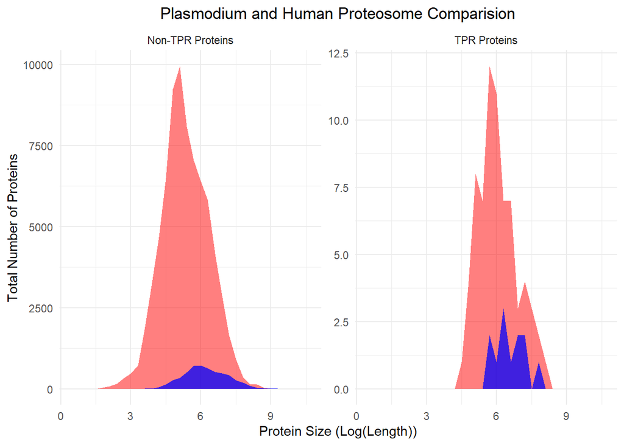

O-Human O-Plasmodium

### Identifying Changes In TPR Expression Through Infection

*All* proteins that were identified as potential *Plasmodium* Hsp90 co-chaperones were extracted from the RNAseq data set to compare their expression throughout the course of infection in the following heat map:

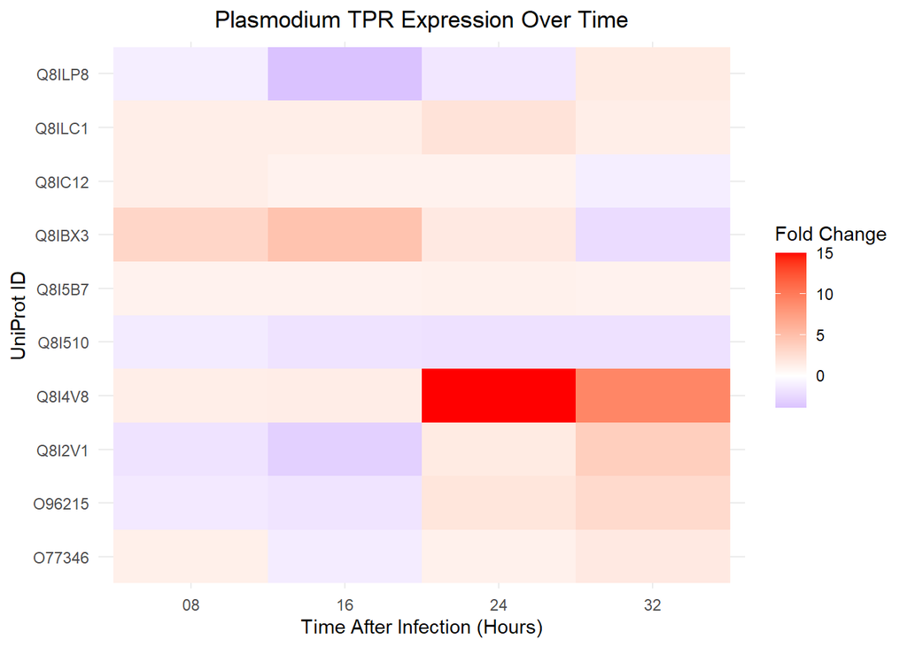

### Comparing FKBP35 Expression to Hsp90

UniProt ID Q814V8 was the most upregulated throughout infection, and this turns out to correspond to the protein FKBP35.The expression of FKBP35 was then compared to Hsp90 (identified from the datasets by it conserved **MEEVD** motif) over the course of infection to determine any correlation:

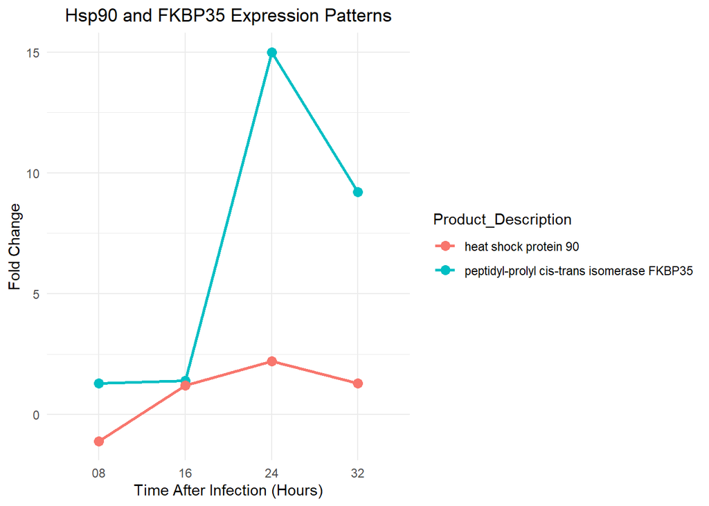

## Conclustions

### Summary

Overall, this approach was able to extract potential Hsp90 co-chaperones from the *Plasmodium* proteome. Most potential co-chaperones did not exhibit differential expression throughout blood-stage infection, except for FKBP35. FKBP are well known Hsp90 binding proteins, supporting this method of identification. FKBP35 has some preliminary data supporting its binding to Hsp90, but the significance of this interaction does not seems to be entirely determined. Hsp90 itself also has an increase in expression at comparable time points. The ~2.5 fold increase does not seem as drastic as FKBP35’s ~15 fold increase, but Hsp90 already comprises 1-2% of cytosolic proteins under normal conditions and a 2-fold increase is about what is expected in response to environmental stress. OVerall, this study has identified an interesting lead into FKBP35 as a co-chaperone with Hsp90 involved in proteostasis at the early stages of *Plasmodium* blood infection.

### Follow-up Studies

Future studies could be conducted to 1) confirm the binding of Hsp90 to FKBP35, and 2) to investigate FKBP35’s role in blood-stage development. Binding studies could be conducted by completing co-immunoprecipitation for FKBP35 in heat shock (Hsp90-enriched) specimen. Knock-out with siRNA could then be conducted to assess loss of FKBP35 in infection. Heat shock could be added as an additional variable to assess its direct effects on Hsp90 stress response pathways.

### Acknowledgements

Thank you to Prof Hirschey and the entire TidyBiology class for this helpful intro to R!

### References

HSP90 Info: Taipale M, Jarosz DF, Lindquist S. 2010. HSP90 at the hub of protein homeostasis: emerging mechanistic insights. Nat Rev Mol Cell Biol 11: 515–528

Plasmodium Specific HSP90: Banumathy G, Singh V, Pavithra SR, Tatu U. Heat shock protein 90 function is essential for Plasmodium falciparum growth in human erythrocytes. J Biol Chem. 2003;278(20):18336- 18345

TPR Motif: Clemens Scheufler, Achim Brinker, Gleb Bourenkov, Stefano Pegoraro, Luis Moroder, Hans Bartunik, F.Ulrich Hartl, Ismail Moarefi, Structure of TPR Domain–Peptide Complexes: Critical Elements in the Assembly of the Hsp70–Hsp90 Multichaperone Machine, Cell,Volume 101, Issue 2,2000,Pages 199-210,

FKBP35: Alag R, Bharatham N, Dong A, et al. Crystallographic structure of the tetratricopeptide repeat domain of Plasmodium falciparum FKBP35 and its molecular interaction with Hsp90 C-terminal pentapeptide. Protein Sci. 2009;18(10):2115-2124. doi:10.1002/pro.226